# Hands-on-exercise8

LI XINYUE

2026-06-12

Chapter 17 Visualising and Analysing Time-oriented Data

17.1 Learning Outcome

By the end of this hands-on exercise you will be able create the followings data visualisation by using R packages:

plotting a calender heatmap by using ggplot2 functions,

plotting a cycle plot by using ggplot2 function,

plotting a slopegraph

plotting a horizon chart

17.2 Getting Started

17.3 Do It Yourself

Write a code chunk to check, install and launch the following R packages: scales, viridis, lubridate, ggthemes, gridExtra, readxl, knitr, data.table and tidyverse.

17.4 Plotting Calendar Heatmap

In this section, you will learn how to plot a calender heatmap programmatically by using ggplot2 package.

By the end of this section, you will be able to:

plot a calender heatmap by using ggplot2 functions and extension, to write function using R programming, to derive specific date and time related field by using base R and lubridate packages to perform data preparation task by using tidyr and dplyr packages.

17.4.1 The Data For the purpose of this hands-on exercise, eventlog.csv file will be used. This data file consists of 199,999 rows of time-series cyber attack records by country.

17.4.2 Importing the data First, you will use the code chunk below to import eventlog.csv file into R environment and called the data frame as attacks.

```r
attacks <- read_csv("eventlog.csv")
```

17.4.3 Examining the data structure It is always a good practice to examine the imported data frame before further analysis is performed.

For example, kable() can be used to review the structure of the imported data frame.

```r
kable(head(attacks))
```

| timestamp | source_country | tz |
| --- | --- | --- |
| 2015-03-12 15:59:16 | CN | Asia/Shanghai |
| 2015-03-12 16:00:48 | FR | Europe/Paris |
| 2015-03-12 16:02:26 | CN | Asia/Shanghai |
| 2015-03-12 16:02:38 | US | America/Chicago |
| 2015-03-12 16:03:22 | CN | Asia/Shanghai |
| 2015-03-12 16:03:45 | CN | Asia/Shanghai |

There are three columns, namely timestamp, source_country and tz.

timestamp field stores date-time values in POSIXct format. source_country field stores the source of the attack. It is in ISO 3166-1 alpha-2 country code. tz field stores time zone of the source IP address.

17.4.4 Data Preparation Step 1: Deriving weekday and hour of day fields

Before we can plot the calender heatmap, two new fields namely wkday and hour need to be derived. In this step, we will write a function to perform the task.

```r
make_hr_wkday <- function(ts, sc, tz) {
  real_times <- ymd_hms(ts,
                        tz = tz[1],
                        quiet = TRUE)
  dt <- data.table(source_country = sc,
                   wkday = weekdays(real_times),
                   hour = hour(real_times))
  return(dt)
  }
```

Step 2: Deriving the attacks tibble data frame

```r
wkday_levels <- c('Saturday', 'Friday',
                  'Thursday', 'Wednesday',
                  'Tuesday', 'Monday',
                  'Sunday')

attacks <- attacks %>%
  group_by(tz) %>%
  do(make_hr_wkday(.$timestamp,
                   .$source_country,
                   .$tz)) %>%
  ungroup() %>%
  mutate(wkday = factor(
    wkday, levels = wkday_levels),
    hour  = factor(
      hour, levels = 0:23))
```

Table below shows the tidy tibble table after processing.

```r
kable(head(attacks))
```

| tz | source_country | wkday | hour |
| --- | --- | --- | --- |
| Africa/Cairo | BG | Saturday | 20 |
| Africa/Cairo | TW | Sunday | 6 |
| Africa/Cairo | TW | Sunday | 8 |
| Africa/Cairo | CN | Sunday | 11 |
| Africa/Cairo | US | Sunday | 15 |
| Africa/Cairo | CA | Monday | 11 |

17.4.5 Building the Calendar Heatmaps

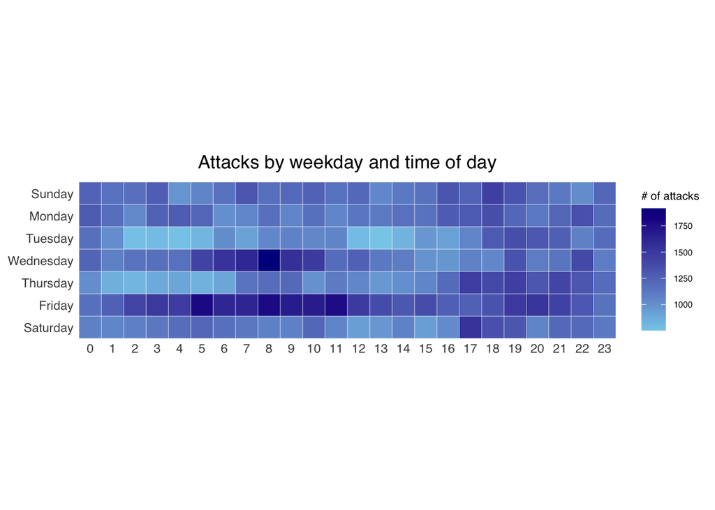

```r
grouped <- attacks %>%
  count(wkday, hour) %>%
  ungroup() %>%
  na.omit()

ggplot(grouped,
       aes(hour,
           wkday,
           fill = n)) +
geom_tile(color = "white",
          size = 0.1) +
theme_tufte(base_family = "Helvetica") +
coord_equal() +
scale_fill_gradient(name = "# of attacks",
                    low = "sky blue",
                    high = "dark blue") +
labs(x = NULL,
     y = NULL,
     title = "Attacks by weekday and time of day") +
theme(axis.ticks = element_blank(),
      plot.title = element_text(hjust = 0.5),
      legend.title = element_text(size = 8),
      legend.text = element_text(size = 6) )
```

Then we can simply group the count by hour and wkday and plot it, since we know that we have values for every combination there’s no need to further preprocess the data.

17.4.6 Building Multiple Calendar Heatmaps Challenge: Building multiple heatmaps for the top four countries with the highest number of attacks.

17.4.7 Plotting Multiple Calendar Heatmaps Step 1: Deriving attack by country object

In order to identify the top 4 countries with the highest number of attacks, you are required to do the followings:

count the number of attacks by country, calculate the percent of attackes by country, and save the results in a tibble data frame.

```r
attacks_by_country <- count(
  attacks, source_country) %>%
  mutate(percent = percent(n/sum(n))) %>%
  arrange(desc(n))
```

Step 2: Preparing the tidy data frame

In this step, you are required to extract the attack records of the top 4 countries from attacks data frame and save the data in a new tibble data frame (i.e. top4_attacks).

```r
top4 <- attacks_by_country$source_country[1:4]
top4_attacks <- attacks %>%
  filter(source_country %in% top4) %>%
  count(source_country, wkday, hour) %>%
  ungroup() %>%
  mutate(source_country = factor(
    source_country, levels = top4)) %>%
  na.omit()
```

17.4.8 Plotting Multiple Calendar Heatmaps Step 3: Plotting the Multiple Calender Heatmap by using ggplot2 package.

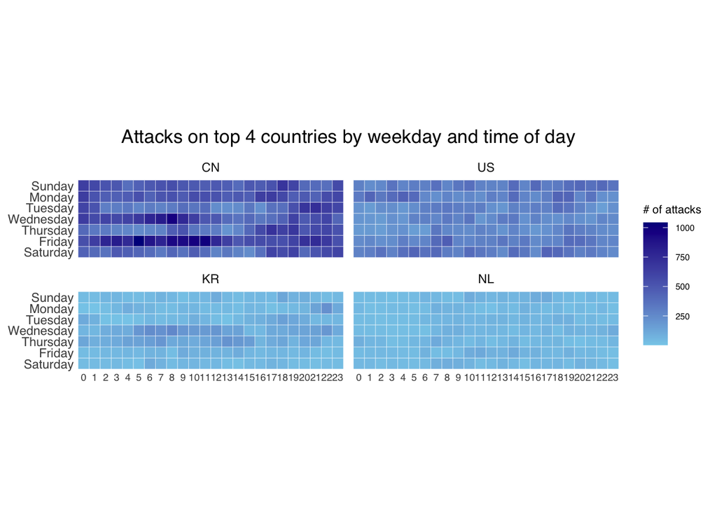

```r
ggplot(top4_attacks,
       aes(hour,
           wkday,
           fill = n)) +
  geom_tile(color = "white",
          size = 0.1) +
  theme_tufte(base_family = "Helvetica") +
  coord_equal() +
  scale_fill_gradient(name = "# of attacks",
                    low = "sky blue",
                    high = "dark blue") +
  facet_wrap(~source_country, ncol = 2) +
  labs(x = NULL, y = NULL,
     title = "Attacks on top 4 countries by weekday and time of day") +
  theme(axis.ticks = element_blank(),
        axis.text.x = element_text(size = 7),
        plot.title = element_text(hjust = 0.5),
        legend.title = element_text(size = 8),
        legend.text = element_text(size = 6) )
```

17.5 Plotting Cycle Plot

In this section, you will learn how to plot a cycle plot showing the time-series patterns and trend of visitor arrivals from Vietnam programmatically by using ggplot2 functions.

17.5.1 Step 1: Data Import For the purpose of this hands-on exercise, arrivals_by_air.xlsx will be used.

The code chunk below imports arrivals_by_air.xlsx by using read_excel() of readxl package and save it as a tibble data frame called air.

```r
air <- read_excel("arrivals_by_air.xlsx")
```

17.5.2 Step 2: Deriving month and year fields Next, two new fields called month and year are derived from Month-Year field.

```r
air$month <- factor(month(air$`Month-Year`),
                    levels=1:12,
                    labels=month.abb,
                    ordered=TRUE)
air$year <- year(ymd(air$`Month-Year`))
```

17.5.3 Step 4: Extracting the target country Next, the code chunk below is use to extract data for the target country (i.e. Vietnam)

```r
Vietnam <- air %>%
  select(`Vietnam`,
         month,
         year) %>%
  filter(year >= 2010)
```

17.5.4 Step 5: Computing year average arrivals by month The code chunk below uses group_by() and summarise() of dplyr to compute year average arrivals by month.

```r
hline.data <- Vietnam %>%
  group_by(month) %>%
  summarise(avgvalue = mean(`Vietnam`))
```

17.5.5 Srep 6: Plotting the cycle plot The code chunk below is used to plot the cycle plot as shown in Slide 12/23.

```
## Ignoring unknown labels:
## • axis.text.x : <object>
```

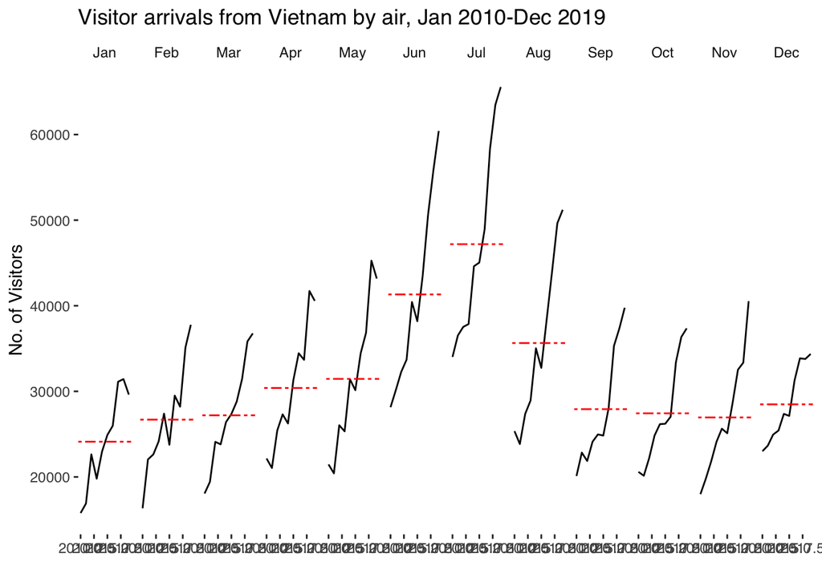

```r
ggplot() +
  geom_line(data=Vietnam,
            aes(x=year,
                y=`Vietnam`,
                group=month),
            colour="black") +
  geom_hline(aes(yintercept=avgvalue),
             data=hline.data,
             linetype=6,
             colour="red",
             size=0.5) +
  facet_grid(~month) +
  labs(axis.text.x = element_blank(),
       title = "Visitor arrivals from Vietnam by air, Jan 2010-Dec 2019") +
  xlab("") +
  ylab("No. of Visitors") +
  theme_tufte(base_family = "Helvetica")
```

17.6 Plotting Slopegraph

In this section you will learn how to plot a slopegraph by using R.

Before getting start, make sure that CGPfunctions has been installed and loaded onto R environment. Then, refer to Using newggslopegraph to learn more about the function. Lastly, read more about newggslopegraph() and its arguments by referring to this link.

17.6.1 Step 1: Data Import Import the rice data set into R environment by using the code chunk below.

```r
rice <- read_csv("rice.csv")
```

17.6.2 Step 2: Plotting the slopegraph Next, code chunk below will be used to plot a basic slopegraph as shown below.

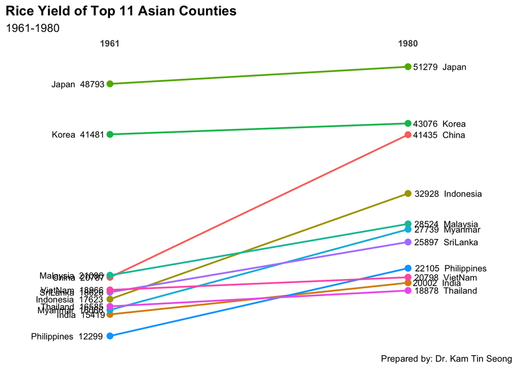

```r
rice %>%
  mutate(Year = factor(Year)) %>%
  filter(Year %in% c(1961, 1980)) %>%
  ggplot(aes(x = Year, y = Yield, group = Country)) +
  geom_line(aes(color = Country), linewidth = 0.8, show.legend = FALSE) +
  geom_point(aes(color = Country), size = 2.5, show.legend = FALSE) +
  geom_text(
    data = . %>% filter(Year == 1961),
    aes(label = paste0(Country, "  ", round(Yield))),
    hjust = 1.1, size = 3
  ) +
  geom_text(
    data = . %>% filter(Year == 1980),
    aes(label = paste0(round(Yield), "  ", Country)),
    hjust = -0.1, size = 3
  ) +
  scale_x_discrete(position = "top", expand = expansion(mult = 0.35)) +
  labs(
    title    = "Rice Yield of Top 11 Asian Counties",
    subtitle = "1961-1980",
    caption  = "Prepared by: Dr. Kam Tin Seong"
  ) +
  theme_minimal() +
  theme(
    axis.title     = element_blank(),
    axis.text.y    = element_blank(),
    axis.text.x    = element_text(face = "bold"),
    panel.grid     = element_blank(),
    plot.title     = element_text(face = "bold")
  )
```

[output not shown]